# Mini curso: Análisis de enriquecimiento funcional de conjuntos de genes en R

Robert Castelo - Universidad Pompeu Fabra - Barcelona - robert.castelo@upf.edu - @robertclab  
12 de junio de 2021

[figure not shown]

[figure not shown]

### Vías biológicas diferencialmente expresadas

- La interpretación de una lista de genes diferencialmente expresados (DE) suele ser más util cuando la hacemos en términos de vías biológicas (*biological pathways*).
- Una **vía biológica** es una serie de acciones entre moléculas de una célula que conduce a un determinado producto o a un cambio en la célula; vean la página educacional correspondiente del [NHGRI](https://www.genome.gov/es/about-genomics/fact-sheets/Vias-Biologicas) para una descripción más ámplia.
- Dado que los genes actúan colectivamente bajo el control de programas de regulación molecular, un modelo más cercano a la biología subyacente es aquel en que las vías biológicas son las que se expresan diferencialmente.
- Una aproximación sería intentar hacer el análisis de expresión diferencial **directamente** a nivel de vía biológica, o **indirectamente** buscando la sobre-representación (enriquecimiento) de nuestros genes DE en cada vía de **interés**.

### Definiciones de vías biológicas

- Consideremos primero restrigir la búsqueda de vías biológicas DE a aquellas que son conocidas.
- Bases de datos como [Reactome](https://www.reactome.org) o [KEGG](https://www.genome.jp/kegg) anotan información de la literatura sobre los genes, la proteinas and las reacciones que forman las vías biológicas.
- Una forma simple pero muy útil de definir vías biológicas es en terminos de **conjuntos de genes**, irrespectivamente de las interacciones moleculares que pueda haber entre ellos y/o sus productos.
- Hay muchas bases de datos de conjuntos de genes, siendo las más populares [The Gene Ontology (GO) project](http://geneontology.org) y [The Molecular Signatures Database (MSigDB)](https://www.gsea-msigdb.org/gsea/msigdb).
- A menudo las bases de datos no incluyen las vías biológicas que són más relevantes al sistema que estamos estudiando. En tal caso, deberíamos de o bien curar nuestros propios conjuntos de genes, o bien utilizar técnicas para inferirlos a partir de los datos.

### Definiciones de vías biológicas

- Por ejemplo, piensen en genes que codifican por proteinas involucradas en la respuesta inmune innata. Concretamente, aquellos q detectan patógenos humanos.

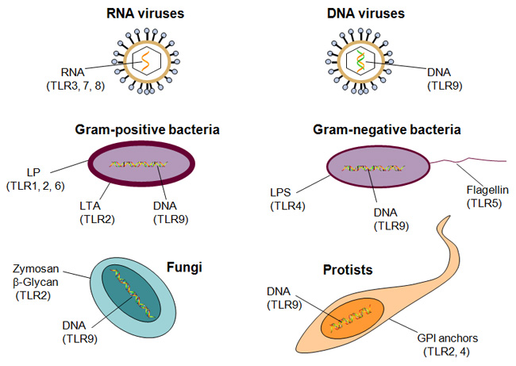

Fig. 1. Christmas P. Toll-Like Receptors: Sensors that Detect Infection. [*Nature Education*, 3(9):85, 2010.](https://www.nature.com/scitable/topicpage/toll-like-receptors-sensors-that-detect-infection-14396559#)

### Idea general del enriquecimiento functional

- Supongamos we estamos comparando muestras de pacientes expuestos a algun tipo de infección con controles. Teniendo en mente la definición de la vía biológica previa, qué podríamos concluir a partir de la siguiente gráfica de tipo volcán?

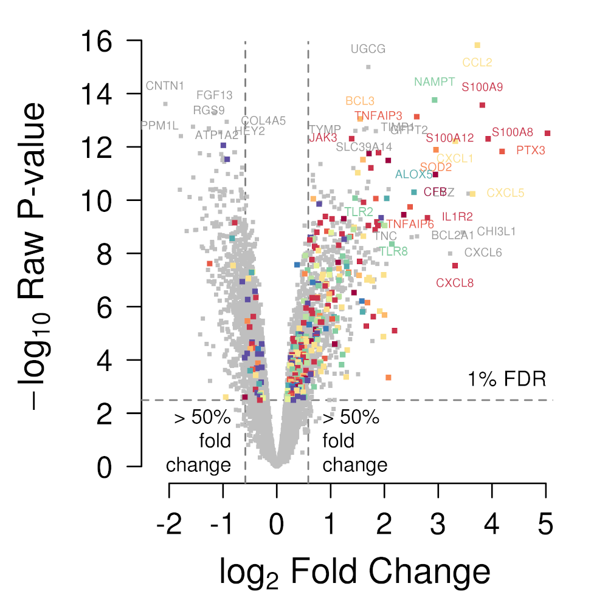

Fig. 1a. Costa D and Castelo R. Umbilical cord gene expression reveals the molecular architecture of the fetal inflammatory response in extremely preterm newborns. [*Pediatric Research*, 79:473-481, 2016.](https://dx.doi.org/10.1038/pr.2015.233)

### Idea general del enriquecimiento functional

- Una forma conveniente de encontrar vías biológicas DE, en términos de conjuntos de genes DE, es detectando lo que se suele llamar un **enriquecimiento funcional** a través de los siguientes dos pasos:
  1. Buscar genes DE.
  2. Para cada conjunto de genes, verificar si esos genes DE pertenecen a ese conjunto en una proporción que excede cualquier expectativa de encontrar ese número de genes en ese conjunto únicamente por azar.
- En este contexto, cuando un conjunto de genes contiene **más** genes DE que los que podríamos esperar por puro azar, decimos que este conjunto de genes esta **enriquecido** en genes DE.
- Una forma fácil de aplicar esta estrategia es utilizando la llamada [prueba exacta de Fisher](https://es.wikipedia.org/wiki/Prueba_exacta_de_Fisher) (también conocida como prueba hipergeométrica).

### Prueba exacta de Fisher

- **Hipótesis nula**: el conjunto de genes no incluye más genes DE que los que podríamos esperar únicamente por azar. Esta hipótesis nula se suele formalizar con el llamado **modelo de la urna**:

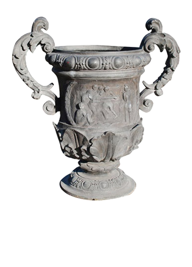

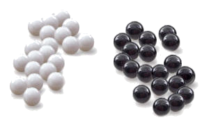

- Universo de genes: todos los genes que **consideramos**.
- Hay una bola en la urna para cada gen del universo de genes.
- Cada bola está etiquetada con un único identificador de gen.
- Las bolas blancas representan genes **DE**.
- Las bolas negras representan genes **no-DE**.
- Sacar a ciegas (uniformemente al azar) tantas bolas de la urna como genes tenemos en el conjunto de genes para el que hacemos la prueba, sin volverlas a poner en la urna (muestreo **sin reemplazamiento**).
- El número de **bolas blancas** sacadas de esta manera de la urna (i.e., el número de genes DE del conjunto para el que hacemos la prueba) sigue una [distribución hipergeométrica](https://es.wikipedia.org/wiki/Distribuci%C3%B3n_hipergeom%C3%A9trica).

### Prueba exacta de Fisher

- Consideramos las siguientes cantidades:
  - \( N \) es el número total de genes **considerados** (tamaño de nuestro universo de genes).
  - \( n \) es el número de genes DE.
  - \( m \) es el número de genes del conjunto para el que hacemos la prueba.
  - \( k \) es el número de genes DE en el conjunto para el que hacemos la prueba.
- La [prueba exacta de Fisher](https://es.wikipedia.org/wiki/Prueba_exacta_de_Fisher) se utiliza ampliamente en el análisis de tablas de contingencia resultantes de clasificar objetos a través de dos factores los cuales en nuestro caso son la pertenencia a un conjunto de genes y si un gen es DE o no:

|  | DE | non-DE | Total |
| --- | --- | --- | --- |
| INSIDE GENE SET | \( k \) | \( m-k \) | \( m \) |
| OUTSIDE GENE SET | \( n-k \) | \( N+k-n-m \) | \( N-m \) |
| TOTAL | \( n \) | \( N-n \) | \( N \) |